# Assignment 15

Nathan Angell

11/29/2021

```r
library(tidytext)
library(ggpubr)
library(tidyverse)
library(knitr)
library(lubridate)
```

### 1. Write a function to calculate the age of a person. Give an example to test your function.

- Input: a number, x, (year born)
- Output: Print out “You are r age”. Where r is the age of the person, i.e. 2020 - x.

```r
age <- function(x)
{
  r = 2021-x
  print(paste0('You are ', r, ' years old.'))
}

age(1999)
```

```
## [1] "You are 22 years old."
```

### 2. Write the following function. Give an example to test your function.

- Input: a number
- Output: print out: “Your input is an even number!” if the number is not even, or “You input an odd number!” otherwise.

```r
num <- function(x)
{
  if((x %% 2) == 0)
  {
  print(paste(x,"is Even"))
  } else
  {
  print(paste(x,"is Odd"))
  }
}

num(3)
```

```
## [1] "3 is Odd"
```

```r
num(4)
```

```
## [1] "4 is Even"
```

### 3. Write the following function. Give an example to test your function.

- Input: a numeric vector
- Output:
  - if the input vector has missing values: return the input vector with missing values replaced by mean
  - if the input vector has no missing value: return the same input vector

```r
mean_impute <- function(x)
{
  if(sum(is.na(x))>0)
  {
    # Find the mean of x
    mean_of_x <- mean(x, na.rm = TRUE)
    # Replace the missing with mean
    library(tidyr)
    x <- replace_na(x, mean_of_x)
  }
return(x)
}

x <- c(1,2,5,3,NaN,6,7,NaN)

mean_impute(x)
```

```
## [1] 1 2 5 3 4 6 7 4
```

### 4. Write the following function. Give an example to test your function.

- Input: a vector x
- Output: The vector x where the missing values replaced by the mean (if x is numeric) or the mode (if x is non-numeric). If x does not have missing value, return the same vector x.

```r
impute <- function(x)
{
  if(is.numeric(x))
  {
    # Find the mean of x
    mean_of_x <- mean(x, na.rm = TRUE)
    # Replace the missing with mean
    x <- replace_na(x, mean_of_x)
  }

  else {
    library(tidyr)
     # Find the mean of x
     mode_of_x <- names(sort(-table(x)))[1]
    # Replace the missing with mean
    x <- replace_na(x, mode_of_x)

  }
return(x)
}

x <- c(1,NA,3,NA,5,8)
impute(x)
```

```
## [1] 1.00 4.25 3.00 4.25 5.00 8.00
```

```r
x <- c('a','b','a','a','z',NA,'d', NA)
impute(x)
```

```
## [1] "a" "b" "a" "a" "z" "a" "d" "a"
```

### 5. Write the following function. Give examples to test your function.

- Input: A data frame of two variables x and y
- Output:
  - A boxplot of x by y if x is numeric and y is non-numeric
  - A boxplot of y by x if y is numeric and x is non-numeric
  - print out ‘This function cannot visualize your data’ otherwise

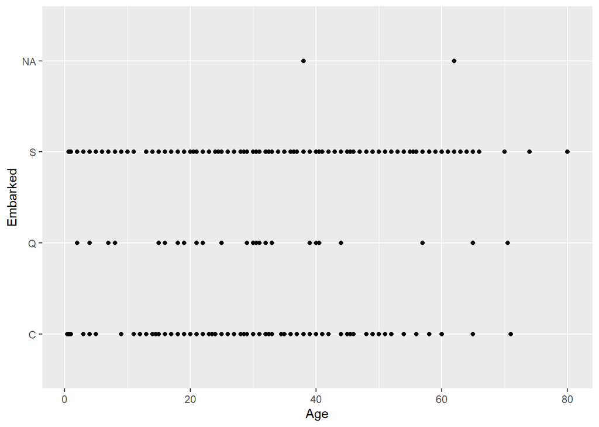

```r
viz <- function(d)
{
  if(is.numeric(d[[1]])& is.character(d[[2]]))
  {
    d %>% ggplot(aes(x = d[[1]], y = d[[2]]))+
      geom_point()+
      labs(x = names(d)[1], y = names(d)[2])
  }
  else if ((is.numeric(d[[2]])& is.character(d[[1]])))
  {
    d %>% ggplot(aes(x = d[[2]], fill = d[[1]]))+
      geom_bar(position = 'dodge')+
      labs(x = names(d)[2], fill = names(d)[1])
  }
  else
  {
    print('This function cannot visualize your data.')
  }
}

df <- read_csv("titanic.csv")
d <- df %>% select(Age, Embarked)
viz(d)
```

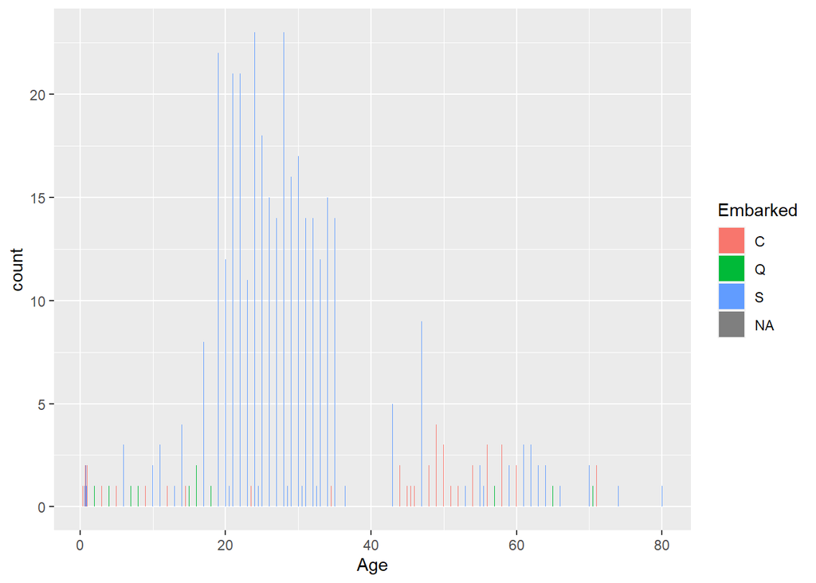

```r
d <- df %>% select(Embarked, Age)
viz(d)
```